# 非Tiey Data轉換成Tidy Data

wuyijin

2019年2月13日

- Tidy Data三個條件(normal principle)
  - 1.每個變數(variable)都會形成一個column
  - 2.每個觀察個體(observation)都會形成一個row
  - 3.每一種類型的觀察個體會形成一個table,比如說:地區特徵跟個體資料應該存成兩個不同的資料表格

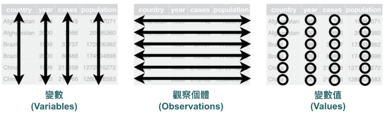

- tidyr套件 - 將不符合tidy原則的資料集合整理成tidy data

  ```r
  # install.packages("tidyverse")
  library(readr)
  library(tidyr)
  ```

- non-tidy data四種可能性
  - Column是值而不是變數 - Gather

    ```r
    pew <- read_delim("http://stat405.had.co.nz/data/pew.txt",delim="\t")
    pew
    ```

    ```
    ## # A tibble: 18 x 11
    ##    religion `<$10k` `$10-20k` `$20-30k` `$30-40k` `$40-50k` `$50-75k`
    ##    <chr>      <dbl>     <dbl>     <dbl>     <dbl>     <dbl>     <dbl>
    ##  1 Agnostic      27        34        60        81        76       137
    ##  2 Atheist       12        27        37        52        35        70
    ##  3 Buddhist      27        21        30        34        33        58
    ##  4 Catholic     418       617       732       670       638      1116
    ##  5 Don’t k~      15        14        15        11        10        35
    ##  6 Evangel~     575       869      1064       982       881      1486
    ##  7 Hindu          1         9         7         9        11        34
    ##  8 Histori~     228       244       236       238       197       223
    ##  9 Jehovah~      20        27        24        24        21        30
    ## 10 Jewish        19        19        25        25        30        95
    ## 11 Mainlin~     289       495       619       655       651      1107
    ## 12 Mormon        29        40        48        51        56       112
    ## 13 Muslim         6         7         9        10         9        23
    ## 14 Orthodox      13        17        23        32        32        47
    ## 15 Other C~       9         7        11        13        13        14
    ## 16 Other F~      20        33        40        46        49        63
    ## 17 Other W~       5         2         3         4         2         7
    ## 18 Unaffil~     217       299       374       365       341       528
    ## # ... with 4 more variables: `$75-100k` <dbl>, `$100-150k` <dbl>,
    ## #   `>150k` <dbl>, `Don't know/refused` <dbl>
    ```

  - gather(data,key = “key”,value = “value”, …,na.rm = FALSE,convert = FALSE,factor_key = FALSE)
    - data：待處理的資料
    - key：新變數的欄位名稱
    - value：新變數變數值的儲存欄位名稱
    - …：要被蒐集起來變成新變數的 columns
    - na.rm：是否刪除遺失值資料
    - convert：轉換特殊格式

    ```
    ## # A tibble: 180 x 3
    ##    religion                income cases
    ##    <chr>                   <chr>  <dbl>
    ##  1 Agnostic                <$10k     27
    ##  2 Atheist                 <$10k     12
    ##  3 Buddhist                <$10k     27
    ##  4 Catholic                <$10k    418
    ##  5 Don’t know/refused      <$10k     15
    ##  6 Evangelical Prot        <$10k    575
    ##  7 Hindu                   <$10k      1
    ##  8 Historically Black Prot <$10k    228
    ##  9 Jehovah's Witness       <$10k     20
    ## 10 Jewish                  <$10k     19
    ## # ... with 170 more rows
    ```

  - 把變數當成值 - spread

    ```r
    table2
    ```

    ```
    ## # A tibble: 12 x 4
    ##    country      year type            count
    ##    <chr>       <int> <chr>           <int>
    ##  1 Afghanistan  1999 cases             745
    ##  2 Afghanistan  1999 population   19987071
    ##  3 Afghanistan  2000 cases            2666
    ##  4 Afghanistan  2000 population   20595360
    ##  5 Brazil       1999 cases           37737
    ##  6 Brazil       1999 population  172006362
    ##  7 Brazil       2000 cases           80488
    ##  8 Brazil       2000 population  174504898
    ##  9 China        1999 cases          212258
    ## 10 China        1999 population 1272915272
    ## 11 China        2000 cases          213766
    ## 12 China        2000 population 1280428583
    ```

  - spread(data,key,value,fill = NA,convert = FALSE,drop = TRUE,sep = NULL)
    - key：要被拆開成variables的column
    - sep：如果是NULL，會直接將key的值當成新colmun的名稱，如果輸入其他分隔符號，會回傳：“paste0(key_name,sep,key_value)”。

    ```r
    table2 %>%
      spread(key=type,
             value=count,
             sep='_')
    ```

    ```
    ## # A tibble: 6 x 4
    ##   country      year type_cases type_population
    ##   <chr>       <int>      <int>           <int>
    ## 1 Afghanistan  1999        745        19987071
    ## 2 Afghanistan  2000       2666        20595360
    ## 3 Brazil       1999      37737       172006362
    ## 4 Brazil       2000      80488       174504898
    ## 5 China        1999     212258      1272915272
    ## 6 China        2000     213766      1280428583
    ```

  - 多個變數儲存在同一個column中 - separate

    ```r
    tb <- read_csv("https://raw.githubusercontent.com/yijinwu1/R/master/excel/tb.csv")
    tb
    ```

    ```
    ## # A tibble: 5,769 x 23
    ##    iso2   year new_sp `m_0-4` `m_5-14` `m_0-14` `m_15-24` `m_25-34`
    ##    <chr> <dbl>  <dbl>   <dbl>    <dbl>    <dbl>     <dbl>     <dbl>
    ##  1 AD     1989     NA      NA       NA       NA        NA        NA
    ##  2 AD     1990     NA      NA       NA       NA        NA        NA
    ##  3 AD     1991     NA      NA       NA       NA        NA        NA
    ##  4 AD     1992     NA      NA       NA       NA        NA        NA
    ##  5 AD     1993     15      NA       NA       NA        NA        NA
    ##  6 AD     1994     24      NA       NA       NA        NA        NA
    ##  7 AD     1996      8      NA       NA        0         0         0
    ##  8 AD     1997     17      NA       NA        0         0         1
    ##  9 AD     1998      1      NA       NA        0         0         0
    ## 10 AD     1999      4      NA       NA        0         0         0
    ## # ... with 5,759 more rows, and 15 more variables: `m_35-44` <dbl>,
    ## #   `m_45-54` <dbl>, `m_55-64` <dbl>, m_65 <dbl>, m_unknown <dbl>,
    ## #   `f_0-4` <dbl>, `f_5-14` <dbl>, `f_0-14` <dbl>, `f_15-24` <dbl>,
    ## #   `f_25-34` <dbl>, `f_35-44` <dbl>, `f_45-54` <dbl>, `f_55-64` <dbl>,
    ## #   f_65 <dbl>, f_unknown <dbl>
    ```

    - 先處理把值存在column

      ```r
      tb.colnames <- colnames(tb)
      tb.new <- tb %>%
        gather(key = "type",
               value="cases",
               tb.colnames[4:ncol(tb)])
      tb.new
      ```

      ```
      ## # A tibble: 115,380 x 5
      ##    iso2   year new_sp type  cases
      ##    <chr> <dbl>  <dbl> <chr> <dbl>
      ##  1 AD     1989     NA m_0-4    NA
      ##  2 AD     1990     NA m_0-4    NA
      ##  3 AD     1991     NA m_0-4    NA
      ##  4 AD     1992     NA m_0-4    NA
      ##  5 AD     1993     15 m_0-4    NA
      ##  6 AD     1994     24 m_0-4    NA
      ##  7 AD     1996      8 m_0-4    NA
      ##  8 AD     1997     17 m_0-4    NA
      ##  9 AD     1998      1 m_0-4    NA
      ## 10 AD     1999      4 m_0-4    NA
      ## # ... with 115,370 more rows
      ```

    - separate(data,col,into,sep = “[^[:alnum:]]+”,remove = TRUE,convert = FALSE,extra = “warn”,fill = “warn”,…)
      - col：需要被分開column的名稱
      - into：分隔成新columns的名稱
      - sep：用來分隔欄位的分隔符號，以正規表達式 (regular expression) 表示。

      ```r
      tb.new %>%
        separate(col=type,
                 into=c("gender","age"),
                 sep="_",
                 convert=TRUE)
      ```

      ```
      ## # A tibble: 115,380 x 6
      ##    iso2   year new_sp gender age   cases
      ##    <chr> <dbl>  <dbl> <chr>  <chr> <dbl>
      ##  1 AD     1989     NA m      0-4      NA
      ##  2 AD     1990     NA m      0-4      NA
      ##  3 AD     1991     NA m      0-4      NA
      ##  4 AD     1992     NA m      0-4      NA
      ##  5 AD     1993     15 m      0-4      NA
      ##  6 AD     1994     24 m      0-4      NA
      ##  7 AD     1996      8 m      0-4      NA
      ##  8 AD     1997     17 m      0-4      NA
      ##  9 AD     1998      1 m      0-4      NA
      ## 10 AD     1999      4 m      0-4      NA
      ## # ... with 115,370 more rows
      ```

  - 一個變數被分存在不同 columns 中 - unite

    ```r
    tb <- read_csv("https://raw.githubusercontent.com/yijinwu1/R/master/excel/tb_new.csv")
    tb
    ```

    ```
    ## # A tibble: 103,844 x 7
    ##    iso2   year new_sp gender age_lb age_ub cases
    ##    <chr> <dbl>  <dbl> <chr>   <dbl>  <dbl> <dbl>
    ##  1 AD     1989     NA m           0      4    NA
    ##  2 AD     1990     NA m           0      4    NA
    ##  3 AD     1991     NA m           0      4    NA
    ##  4 AD     1992     NA m           0      4    NA
    ##  5 AD     1993     15 m           0      4    NA
    ##  6 AD     1994     24 m           0      4    NA
    ##  7 AD     1996      8 m           0      4    NA
    ##  8 AD     1997     17 m           0      4    NA
    ##  9 AD     1998      1 m           0      4    NA
    ## 10 AD     1999      4 m           0      4    NA
    ## # ... with 103,834 more rows
    ```

    - unite(data,col,…,sep = “_“,remove = TRUE)
      - col：合併完成後的新 column 名稱
      - …：用來合併的原有 columns 名稱
      - sep：用來分隔欄位的分隔符號，以正規表達式 (regular expression) 表示

    ```r
    tb %>%
      unite(col="age",
            c("age_lb","age_ub"),
            sep="-")
    ```

    ```
    ## # A tibble: 103,844 x 6
    ##    iso2   year new_sp gender age   cases
    ##    <chr> <dbl>  <dbl> <chr>  <chr> <dbl>
    ##  1 AD     1989     NA m      0-4      NA
    ##  2 AD     1990     NA m      0-4      NA
    ##  3 AD     1991     NA m      0-4      NA
    ##  4 AD     1992     NA m      0-4      NA
    ##  5 AD     1993     15 m      0-4      NA
    ##  6 AD     1994     24 m      0-4      NA
    ##  7 AD     1996      8 m      0-4      NA
    ##  8 AD     1997     17 m      0-4      NA
    ##  9 AD     1998      1 m      0-4      NA
    ## 10 AD     1999      4 m      0-4      NA
    ## # ... with 103,834 more rows
    ```